# halit bora 360

Introduction:

In this case, our goal was to forecast production values for a plant. We had data of previous production amounts, and we developed a model that will give us future values. We were also given new values through the submission period which helped us to improve our model even better.

Related Literature:

There are some techniques in the literature, and we will try these methods to evaluate which method fits our case better.

We used following libraries

```r
library(data.table)
library(reshape2)
library(GGally)
library(forecast)
library(ggplot2)
library(dplyr)
library(rmarkdown)
```

Firstly, we read the data and assigned them to p_data and w_data

```r
## reading data

p_data <- read.csv("production.csv")

w_data<- read.csv("long_weather.csv")
```

Then, we transformed the data into a wide format using “dcast” funtion from “data.table” package. As can be seen below, data is in wide format now.

```r
wide_w<-dcast(w_data, date + hour ~ variable+lat+lon, value.variable = "var")
head(wide_w)
```

```
##         date hour CLOUD_LOW_LAYER_36.25_33 CLOUD_LOW_LAYER_36.25_33.25
## 1 2021-02-01    0                       45                          31
## 2 2021-02-01    1                       44                          26
## 3 2021-02-01    2                       37                          35
## 4 2021-02-01    3                       43                          45
## 5 2021-02-01    4                       72                          95
## 6 2021-02-01    5                       69                          95
##   CLOUD_LOW_LAYER_36.25_33.5 CLOUD_LOW_LAYER_36.5_33 CLOUD_LOW_LAYER_36.5_33.25
## 1                          3                      53                         10
## 2                         19                      64                         21
## 3                         35                      60                         19
## 4                         46                      51                         24
## 5                         46                      16                         57
## 6                         31                      24                         68
##   CLOUD_LOW_LAYER_36.5_33.5 CLOUD_LOW_LAYER_36.75_33
```

[output cut: 62 more lines]

After that, we deleted some rows since there was no production data available for those days. We used excel to eliminate data which is included in weather data but not in production data, and synchronize the dates. Below is the updated wide weather data.

```r
wide_w_2<-wide_w[!(wide_w$date=="2021-02-20" | wide_w$date=="2021-08-09"|wide_w$date=="2021-08-10"|wide_w$date=="2021-08-11"|wide_w$date=="2022-01-13"|wide_w$date=="2022-01-14"),]
head(wide_w_2)
```

```
##         date hour CLOUD_LOW_LAYER_36.25_33 CLOUD_LOW_LAYER_36.25_33.25
## 1 2021-02-01    0                       45                          31
## 2 2021-02-01    1                       44                          26
## 3 2021-02-01    2                       37                          35
## 4 2021-02-01    3                       43                          45
## 5 2021-02-01    4                       72                          95
## 6 2021-02-01    5                       69                          95
##   CLOUD_LOW_LAYER_36.25_33.5 CLOUD_LOW_LAYER_36.5_33 CLOUD_LOW_LAYER_36.5_33.25
## 1                          3                      53                         10
## 2                         19                      64                         21
## 3                         35                      60                         19
## 4                         46                      51                         24
## 5                         46                      16                         57
## 6                         31                      24                         68
##   CLOUD_LOW_LAYER_36.5_33.5 CLOUD_LOW_LAYER_36.75_33
```

[output cut: 62 more lines]

Since indexes (rownames) were confusing in terms of checking rows of data, we changed row names to null.

```r
rownames(wide_w_2) <- NULL
```

Then, we took first 10896 rows to make dates for weather and production data same.

```r
wide_putin <- wide_w_2[1:10896,]
head(wide_putin)
```

```
##         date hour CLOUD_LOW_LAYER_36.25_33 CLOUD_LOW_LAYER_36.25_33.25
## 1 2021-02-01    0                       45                          31
## 2 2021-02-01    1                       44                          26
## 3 2021-02-01    2                       37                          35
## 4 2021-02-01    3                       43                          45
## 5 2021-02-01    4                       72                          95
## 6 2021-02-01    5                       69                          95
##   CLOUD_LOW_LAYER_36.25_33.5 CLOUD_LOW_LAYER_36.5_33 CLOUD_LOW_LAYER_36.5_33.25
## 1                          3                      53                         10
## 2                         19                      64                         21
## 3                         35                      60                         19
## 4                         46                      51                         24
## 5                         46                      16                         57
## 6                         31                      24                         68
##   CLOUD_LOW_LAYER_36.5_33.5 CLOUD_LOW_LAYER_36.75_33
```

[output cut: 62 more lines]

After that, we controlled false values due to missing date values in production(p_data).

```r
a <- as.data.frame(wide_putin$date == p_data$date)
head(a)
```

```
##   wide_putin$date == p_data$date
## 1                           TRUE
## 2                           TRUE
## 3                           TRUE
## 4                           TRUE
## 5                           TRUE
## 6                           TRUE
```

Then, we defined a new matrix “son” with production and weather data combined.2

```r
son<-cbind(wide_putin,p_data$production)
head(son)
```

```
##         date hour CLOUD_LOW_LAYER_36.25_33 CLOUD_LOW_LAYER_36.25_33.25
## 1 2021-02-01    0                       45                          31
## 2 2021-02-01    1                       44                          26
## 3 2021-02-01    2                       37                          35
## 4 2021-02-01    3                       43                          45
## 5 2021-02-01    4                       72                          95
## 6 2021-02-01    5                       69                          95
##   CLOUD_LOW_LAYER_36.25_33.5 CLOUD_LOW_LAYER_36.5_33 CLOUD_LOW_LAYER_36.5_33.25
## 1                          3                      53                         10
## 2                         19                      64                         21
## 3                         35                      60                         19
## 4                         46                      51                         24
## 5                         46                      16                         57
## 6                         31                      24                         68
##   CLOUD_LOW_LAYER_36.5_33.5 CLOUD_LOW_LAYER_36.75_33
```

[output cut: 69 more lines]

Model1: All variables included in this model, to have a overall idea. We observe that the model is insufficient. Autocorrelation plot exceeds %95 confidence interval boundaries, that means we left exploitable information in data.

```r
model_1 <- lm(son$`p_data$production` ~ as.factor(hour) + CLOUD_LOW_LAYER_36.25_33 + CLOUD_LOW_LAYER_36.25_33.25 + CLOUD_LOW_LAYER_36.25_33.5 + CLOUD_LOW_LAYER_36.5_33 + CLOUD_LOW_LAYER_36.5_33.25 +
                CLOUD_LOW_LAYER_36.5_33.5 + CLOUD_LOW_LAYER_36.75_33 + CLOUD_LOW_LAYER_36.75_33.25 + CLOUD_LOW_LAYER_36.75_33.5 + DSWRF_36.25_33 + DSWRF_36.25_33.25 + DSWRF_36.25_33.5 + DSWRF_36.5_33 +
                DSWRF_36.5_33.25 + DSWRF_36.5_33.5 + DSWRF_36.75_33 + DSWRF_36.75_33.25 + DSWRF_36.75_33.5 + REL_HUMIDITY_36.25_33 + REL_HUMIDITY_36.25_33.25 + REL_HUMIDITY_36.25_33.5 + REL_HUMIDITY_36.5_33 +
                REL_HUMIDITY_36.5_33.25 + REL_HUMIDITY_36.5_33.5 + REL_HUMIDITY_36.75_33 + REL_HUMIDITY_36.75_33.25 + REL_HUMIDITY_36.75_33.5 + TEMP_36.25_33 + TEMP_36.25_33.25 + TEMP_36.25_33.5 + TEMP_36.5_33 +
                TEMP_36.5_33.25 + TEMP_36.5_33.5 + TEMP_36.75_33 + TEMP_36.75_33.25 + TEMP_36.75_33.5 ,data=son)
summary(model_1)
```

```
##
## Call:
## lm(formula = son$`p_data$production` ~ as.factor(hour) + CLOUD_LOW_LAYER_36.25_33 +
##     CLOUD_LOW_LAYER_36.25_33.25 + CLOUD_LOW_LAYER_36.25_33.5 +
##     CLOUD_LOW_LAYER_36.5_33 + CLOUD_LOW_LAYER_36.5_33.25 + CLOUD_LOW_LAYER_36.5_33.5 +
##     CLOUD_LOW_LAYER_36.75_33 + CLOUD_LOW_LAYER_36.75_33.25 +
##     CLOUD_LOW_LAYER_36.75_33.5 + DSWRF_36.25_33 + DSWRF_36.25_33.25 +
##     DSWRF_36.25_33.5 + DSWRF_36.5_33 + DSWRF_36.5_33.25 + DSWRF_36.5_33.5 +
##     DSWRF_36.75_33 + DSWRF_36.75_33.25 + DSWRF_36.75_33.5 + REL_HUMIDITY_36.25_33 +
##     REL_HUMIDITY_36.25_33.25 + REL_HUMIDITY_36.25_33.5 + REL_HUMIDITY_36.5_33 +
##     REL_HUMIDITY_36.5_33.25 + REL_HUMIDITY_36.5_33.5 + REL_HUMIDITY_36.75_33 +
##     REL_HUMIDITY_36.75_33.25 + REL_HUMIDITY_36.75_33.5 + TEMP_36.25_33 +
##     TEMP_36.25_33.25 + TEMP_36.25_33.5 + TEMP_36.5_33 + TEMP_36.5_33.25 +
##     TEMP_36.5_33.5 + TEMP_36.75_33 + TEMP_36.75_33.25 + TEMP_36.75_33.5,
##     data = son)
##
## Residuals:
##     Min      1Q  Median      3Q     Max
## -35.886  -3.168   0.281   3.397  20.599
##
## Coefficients:
##                               Estimate Std. Error t value Pr(>|t|)
## (Intercept)                 -8.683e+01  3.692e+00 -23.518  < 2e-16 ***
## as.factor(hour)1             6.786e-02  4.075e-01   0.167 0.867759
## as.factor(hour)2             8.662e-02  4.078e-01   0.212 0.831821
## as.factor(hour)3             1.139e-01  4.083e-01   0.279 0.780318
## as.factor(hour)4             1.154e-01  4.091e-01   0.282 0.777891
## as.factor(hour)5             1.810e-01  4.098e-01   0.442 0.658780
## as.factor(hour)6             1.194e+00  4.103e-01   2.909 0.003632 **
## as.factor(hour)7             8.119e+00  4.098e-01  19.812  < 2e-16 ***
## as.factor(hour)8             1.865e+01  4.113e-01  45.334  < 2e-16 ***
## as.factor(hour)9             2.324e+01  4.159e-01  55.888  < 2e-16 ***
## as.factor(hour)10            1.572e+01  4.959e-01  31.709  < 2e-16 ***
## as.factor(hour)11            1.408e+01  5.172e-01  27.216  < 2e-16 ***
## as.factor(hour)12            1.276e+01  5.327e-01  23.951  < 2e-16 ***
## as.factor(hour)13            1.179e+01  5.414e-01  21.771  < 2e-16 ***
## as.factor(hour)14            1.044e+01  5.446e-01  19.179  < 2e-16 ***
## as.factor(hour)15            8.721e+00  5.422e-01  16.084  < 2e-16 ***
## as.factor(hour)16            7.126e+00  5.039e-01  14.141  < 2e-16 ***
## as.factor(hour)17           -1.803e-01  4.801e-01  -0.376 0.707222
```

[output cut: 33 more lines]

```
## TEMP_36.25_33                1.839e-01  1.273e-01   1.445 0.148431
## TEMP_36.25_33.25             9.547e-01  1.813e-01   5.266 1.42e-07 ***
## TEMP_36.25_33.5             -2.942e-01  1.195e-01  -2.462 0.013831 *
## TEMP_36.5_33                 6.531e-02  9.843e-02   0.664 0.506971
## TEMP_36.5_33.25             -3.672e-01  1.665e-01  -2.205 0.027447 *
## TEMP_36.5_33.5               8.554e-03  1.074e-01   0.080 0.936533
## TEMP_36.75_33                6.357e-02  1.087e-01   0.585 0.558830
## TEMP_36.75_33.25             3.111e-01  1.454e-01   2.139 0.032463 *
## TEMP_36.75_33.5             -6.258e-01  1.138e-01  -5.501 3.86e-08 ***
## ---
## Signif. codes:  0 '***' 0.001 '**' 0.01 '*' 0.05 '.' 0.1 ' ' 1
##
## Residual standard error: 6.138 on 10836 degrees of freedom
## Multiple R-squared:  0.8156, Adjusted R-squared:  0.8146
## F-statistic: 812.5 on 59 and 10836 DF,  p-value: < 2.2e-16
```

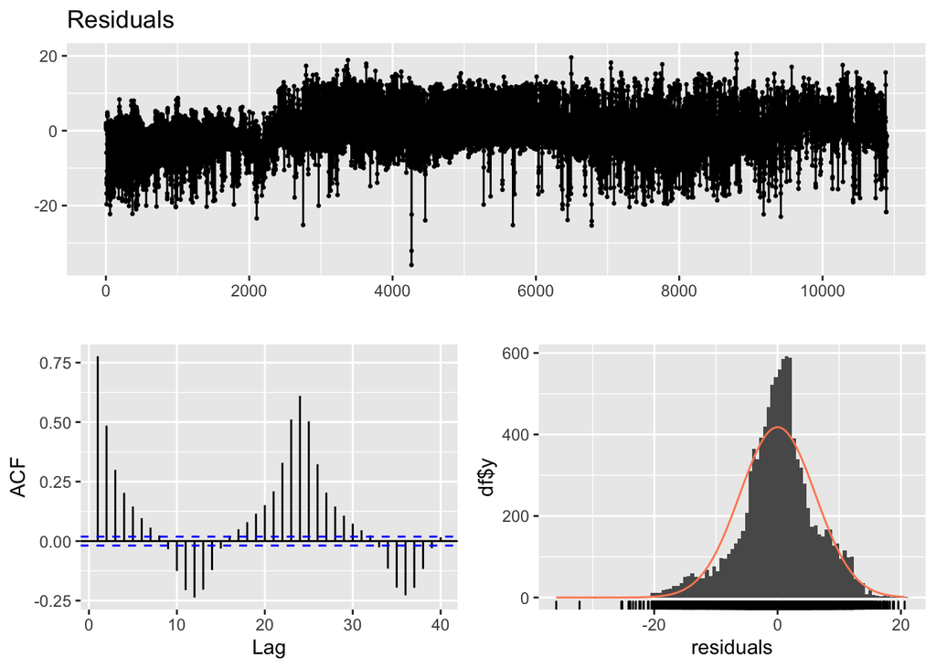

```
##
##  Breusch-Godfrey test for serial correlation of order up to 63
##
## data:  Residuals
## LM test = 8148.5, df = 63, p-value < 2.2e-16
```

```r
checkresiduals(model_1)
```

To understand which part of the data is unrelated, we tried to eliminate whole categories such as DSWRF, CLOUD etc. In this model whole DSWRF information is excluded. This model also has high ACF values and an R-squared value close to previous model.

```r
model_2 <- lm(son$`p_data$production` ~ as.factor(hour) + CLOUD_LOW_LAYER_36.25_33 + CLOUD_LOW_LAYER_36.25_33.25 + CLOUD_LOW_LAYER_36.25_33.5 + CLOUD_LOW_LAYER_36.5_33 + CLOUD_LOW_LAYER_36.5_33.25 +
                CLOUD_LOW_LAYER_36.5_33.5 + CLOUD_LOW_LAYER_36.75_33 + CLOUD_LOW_LAYER_36.75_33.25 + CLOUD_LOW_LAYER_36.75_33.5 + REL_HUMIDITY_36.25_33 + REL_HUMIDITY_36.25_33.25 + REL_HUMIDITY_36.25_33.5 + REL_HUMIDITY_36.5_33 +
                REL_HUMIDITY_36.5_33.25 + REL_HUMIDITY_36.5_33.5 + REL_HUMIDITY_36.75_33 + REL_HUMIDITY_36.75_33.25 + REL_HUMIDITY_36.75_33.5 + TEMP_36.25_33 + TEMP_36.25_33.25 + TEMP_36.25_33.5 + TEMP_36.5_33 +
                TEMP_36.5_33.25 + TEMP_36.5_33.5 + TEMP_36.75_33 + TEMP_36.75_33.25 + TEMP_36.75_33.5 ,data=son)
summary(model_2)
```

```
##
## Call:
## lm(formula = son$`p_data$production` ~ as.factor(hour) + CLOUD_LOW_LAYER_36.25_33 +
##     CLOUD_LOW_LAYER_36.25_33.25 + CLOUD_LOW_LAYER_36.25_33.5 +
##     CLOUD_LOW_LAYER_36.5_33 + CLOUD_LOW_LAYER_36.5_33.25 + CLOUD_LOW_LAYER_36.5_33.5 +
##     CLOUD_LOW_LAYER_36.75_33 + CLOUD_LOW_LAYER_36.75_33.25 +
##     CLOUD_LOW_LAYER_36.75_33.5 + REL_HUMIDITY_36.25_33 + REL_HUMIDITY_36.25_33.25 +
##     REL_HUMIDITY_36.25_33.5 + REL_HUMIDITY_36.5_33 + REL_HUMIDITY_36.5_33.25 +
##     REL_HUMIDITY_36.5_33.5 + REL_HUMIDITY_36.75_33 + REL_HUMIDITY_36.75_33.25 +
##     REL_HUMIDITY_36.75_33.5 + TEMP_36.25_33 + TEMP_36.25_33.25 +
##     TEMP_36.25_33.5 + TEMP_36.5_33 + TEMP_36.5_33.25 + TEMP_36.5_33.5 +
##     TEMP_36.75_33 + TEMP_36.75_33.25 + TEMP_36.75_33.5, data = son)
##
## Residuals:
##     Min      1Q  Median      3Q     Max
## -32.634  -3.473   0.242   4.211  20.092
##
## Coefficients:
##                               Estimate Std. Error t value Pr(>|t|)
## (Intercept)                 -1.067e+02  3.837e+00 -27.814  < 2e-16 ***
## as.factor(hour)1             2.559e-01  4.317e-01   0.593 0.553389
## as.factor(hour)2             4.123e-01  4.320e-01   0.954 0.339888
## as.factor(hour)3             5.568e-01  4.323e-01   1.288 0.197796
## as.factor(hour)4             6.890e-01  4.329e-01   1.591 0.111558
## as.factor(hour)5             8.960e-01  4.335e-01   2.067 0.038737 *
## as.factor(hour)6             1.998e+00  4.339e-01   4.605 4.17e-06 ***
## as.factor(hour)7             8.786e+00  4.336e-01  20.264  < 2e-16 ***
## as.factor(hour)8             1.931e+01  4.351e-01  44.378  < 2e-16 ***
## as.factor(hour)9             2.438e+01  4.391e-01  55.526  < 2e-16 ***
## as.factor(hour)10            2.519e+01  4.447e-01  56.649  < 2e-16 ***
## as.factor(hour)11            2.462e+01  4.511e-01  54.575  < 2e-16 ***
## as.factor(hour)12            2.403e+01  4.565e-01  52.645  < 2e-16 ***
## as.factor(hour)13            2.340e+01  4.606e-01  50.796  < 2e-16 ***
## as.factor(hour)14            2.211e+01  4.633e-01  47.720  < 2e-16 ***
## as.factor(hour)15            2.015e+01  4.651e-01  43.326  < 2e-16 ***
## as.factor(hour)16            1.578e+01  4.681e-01  33.698  < 2e-16 ***
## as.factor(hour)17            6.789e+00  4.649e-01  14.602  < 2e-16 ***
## as.factor(hour)18           -1.026e-01  4.604e-01  -0.223 0.823636
## as.factor(hour)19           -1.715e+00  4.521e-01  -3.793 0.000150 ***
## as.factor(hour)20           -9.592e-01  4.434e-01  -2.163 0.030531 *
```

[output cut: 21 more lines]

```
## TEMP_36.25_33                1.052e-01  1.313e-01   0.801 0.423185
## TEMP_36.25_33.25             1.270e+00  1.881e-01   6.748 1.57e-11 ***
## TEMP_36.25_33.5             -9.816e-01  1.235e-01  -7.949 2.06e-15 ***
## TEMP_36.5_33                 4.490e-01  1.033e-01   4.348 1.39e-05 ***
## TEMP_36.5_33.25             -7.014e-01  1.731e-01  -4.053 5.10e-05 ***
## TEMP_36.5_33.5               9.961e-01  1.095e-01   9.098  < 2e-16 ***
## TEMP_36.75_33               -4.165e-01  1.128e-01  -3.692 0.000224 ***
## TEMP_36.75_33.25             1.223e+00  1.491e-01   8.203 2.62e-16 ***
## TEMP_36.75_33.5             -1.574e+00  1.161e-01 -13.552  < 2e-16 ***
## ---
## Signif. codes:  0 '***' 0.001 '**' 0.01 '*' 0.05 '.' 0.1 ' ' 1
##
## Residual standard error: 6.502 on 10845 degrees of freedom
## Multiple R-squared:  0.7929, Adjusted R-squared:  0.7919
## F-statistic: 830.4 on 50 and 10845 DF,  p-value: < 2.2e-16
```

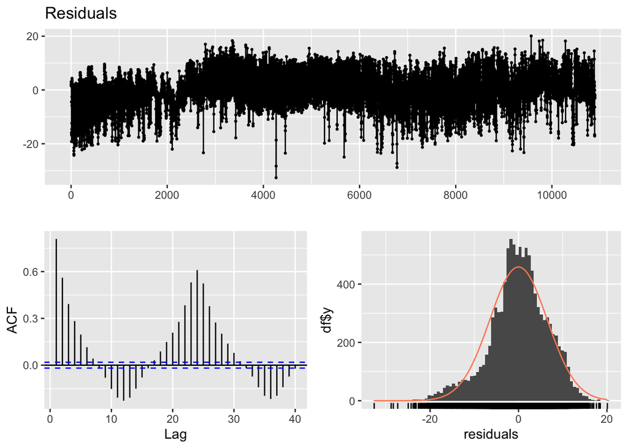

```
##
##  Breusch-Godfrey test for serial correlation of order up to 54
##
## data:  Residuals
## LM test = 8369.5, df = 54, p-value < 2.2e-16
```

```r
checkresiduals(model_2)
```

Previous approach is continued. This time CLOUD data is excluded. The model ve obtain still seems insufficient.

```r
model_3 <- lm(son$`p_data$production` ~ as.factor(hour) + DSWRF_36.25_33 + DSWRF_36.25_33.25 + DSWRF_36.25_33.5 + DSWRF_36.5_33 +
                DSWRF_36.5_33.25 + DSWRF_36.5_33.5 + DSWRF_36.75_33 + DSWRF_36.75_33.25 + DSWRF_36.75_33.5 + REL_HUMIDITY_36.25_33 + REL_HUMIDITY_36.25_33.25 + REL_HUMIDITY_36.25_33.5 + REL_HUMIDITY_36.5_33 +
                REL_HUMIDITY_36.5_33.25 + REL_HUMIDITY_36.5_33.5 + REL_HUMIDITY_36.75_33 + REL_HUMIDITY_36.75_33.25 + REL_HUMIDITY_36.75_33.5 + TEMP_36.25_33 + TEMP_36.25_33.25 + TEMP_36.25_33.5 + TEMP_36.5_33 +
                TEMP_36.5_33.25 + TEMP_36.5_33.5 + TEMP_36.75_33 + TEMP_36.75_33.25 + TEMP_36.75_33.5 ,data=son)
summary(model_3)
```

```
##
## Call:
## lm(formula = son$`p_data$production` ~ as.factor(hour) + DSWRF_36.25_33 +
##     DSWRF_36.25_33.25 + DSWRF_36.25_33.5 + DSWRF_36.5_33 + DSWRF_36.5_33.25 +
##     DSWRF_36.5_33.5 + DSWRF_36.75_33 + DSWRF_36.75_33.25 + DSWRF_36.75_33.5 +
##     REL_HUMIDITY_36.25_33 + REL_HUMIDITY_36.25_33.25 + REL_HUMIDITY_36.25_33.5 +
##     REL_HUMIDITY_36.5_33 + REL_HUMIDITY_36.5_33.25 + REL_HUMIDITY_36.5_33.5 +
##     REL_HUMIDITY_36.75_33 + REL_HUMIDITY_36.75_33.25 + REL_HUMIDITY_36.75_33.5 +
##     TEMP_36.25_33 + TEMP_36.25_33.25 + TEMP_36.25_33.5 + TEMP_36.5_33 +
##     TEMP_36.5_33.25 + TEMP_36.5_33.5 + TEMP_36.75_33 + TEMP_36.75_33.25 +
##     TEMP_36.75_33.5, data = son)
##
## Residuals:
##     Min      1Q  Median      3Q     Max
## -36.033  -3.184   0.322   3.136  19.364
##
## Coefficients:
##                            Estimate Std. Error t value Pr(>|t|)
## (Intercept)              -80.912583   3.629996 -22.290  < 2e-16 ***
## as.factor(hour)1           0.060719   0.409453   0.148 0.882114
## as.factor(hour)2           0.085009   0.409752   0.207 0.835650
## as.factor(hour)3           0.106992   0.410184   0.261 0.794221
## as.factor(hour)4           0.095534   0.410798   0.233 0.816109
## as.factor(hour)5           0.169632   0.411478   0.412 0.680163
## as.factor(hour)6           1.200914   0.412014   2.915 0.003567 **
## as.factor(hour)7           8.119069   0.411558  19.728  < 2e-16 ***
## as.factor(hour)8          18.593554   0.413020  45.019  < 2e-16 ***
## as.factor(hour)9          23.105256   0.417307  55.367  < 2e-16 ***
## as.factor(hour)10         15.256782   0.495078  30.817  < 2e-16 ***
## as.factor(hour)11         13.499655   0.515344  26.195  < 2e-16 ***
## as.factor(hour)12         12.084665   0.529764  22.811  < 2e-16 ***
## as.factor(hour)13         11.057895   0.537645  20.567  < 2e-16 ***
## as.factor(hour)14          9.679976   0.540226  17.918  < 2e-16 ***
## as.factor(hour)15          7.929341   0.537401  14.755  < 2e-16 ***
## as.factor(hour)16          6.292129   0.498261  12.628  < 2e-16 ***
## as.factor(hour)17         -0.920914   0.475773  -1.936 0.052940 .
## as.factor(hour)18         -6.215522   0.457931 -13.573  < 2e-16 ***
## as.factor(hour)19         -6.707084   0.443606 -15.119  < 2e-16 ***
## as.factor(hour)20         -5.313480   0.433028 -12.271  < 2e-16 ***
## as.factor(hour)21         -4.501256   0.425388 -10.582  < 2e-16 ***
```

[output cut: 20 more lines]

```
## TEMP_36.25_33              0.175061   0.124333   1.408 0.159160
## TEMP_36.25_33.25           0.860579   0.179800   4.786 1.72e-06 ***
## TEMP_36.25_33.5           -0.197501   0.118961  -1.660 0.096899 .
## TEMP_36.5_33               0.044170   0.098242   0.450 0.653004
## TEMP_36.5_33.25           -0.436356   0.164910  -2.646 0.008156 **
## TEMP_36.5_33.5            -0.009293   0.107057  -0.087 0.930827
## TEMP_36.75_33              0.099072   0.107773   0.919 0.357975
## TEMP_36.75_33.25           0.527509   0.143857   3.667 0.000247 ***
## TEMP_36.75_33.5           -0.781231   0.111276  -7.021 2.34e-12 ***
## ---
## Signif. codes:  0 '***' 0.001 '**' 0.01 '*' 0.05 '.' 0.1 ' ' 1
##
## Residual standard error: 6.166 on 10845 degrees of freedom
## Multiple R-squared:  0.8137, Adjusted R-squared:  0.8129
## F-statistic: 947.7 on 50 and 10845 DF,  p-value: < 2.2e-16
```

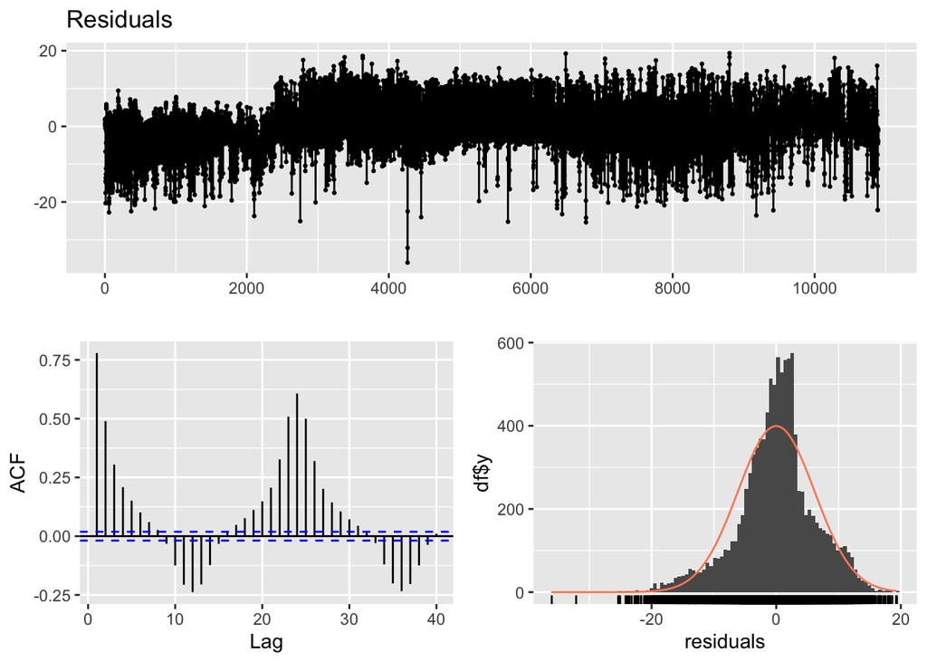

```
##
##  Breusch-Godfrey test for serial correlation of order up to 54
##
## data:  Residuals
## LM test = 8176.2, df = 54, p-value < 2.2e-16
```

```r
checkresiduals(model_3)
```

Previous approach is continued. This time humidity data is excluded. The model ve obtain still seems insufficient.

```r
model_4 <- lm(son$`p_data$production` ~ as.factor(hour) + CLOUD_LOW_LAYER_36.25_33 + CLOUD_LOW_LAYER_36.25_33.25 + CLOUD_LOW_LAYER_36.25_33.5 + CLOUD_LOW_LAYER_36.5_33 + CLOUD_LOW_LAYER_36.5_33.25 +
                CLOUD_LOW_LAYER_36.5_33.5 + CLOUD_LOW_LAYER_36.75_33 + CLOUD_LOW_LAYER_36.75_33.25 + CLOUD_LOW_LAYER_36.75_33.5 + DSWRF_36.25_33 + DSWRF_36.25_33.25 + DSWRF_36.25_33.5 + DSWRF_36.5_33 +
                DSWRF_36.5_33.25 + DSWRF_36.5_33.5 + DSWRF_36.75_33 + DSWRF_36.75_33.25 + DSWRF_36.75_33.5 + TEMP_36.25_33 + TEMP_36.25_33.25 + TEMP_36.25_33.5 + TEMP_36.5_33 +
                TEMP_36.5_33.25 + TEMP_36.5_33.5 + TEMP_36.75_33 + TEMP_36.75_33.25 + TEMP_36.75_33.5 ,data=son)
summary(model_4)
```

```
##
## Call:
## lm(formula = son$`p_data$production` ~ as.factor(hour) + CLOUD_LOW_LAYER_36.25_33 +
##     CLOUD_LOW_LAYER_36.25_33.25 + CLOUD_LOW_LAYER_36.25_33.5 +
##     CLOUD_LOW_LAYER_36.5_33 + CLOUD_LOW_LAYER_36.5_33.25 + CLOUD_LOW_LAYER_36.5_33.5 +
##     CLOUD_LOW_LAYER_36.75_33 + CLOUD_LOW_LAYER_36.75_33.25 +
##     CLOUD_LOW_LAYER_36.75_33.5 + DSWRF_36.25_33 + DSWRF_36.25_33.25 +
##     DSWRF_36.25_33.5 + DSWRF_36.5_33 + DSWRF_36.5_33.25 + DSWRF_36.5_33.5 +
##     DSWRF_36.75_33 + DSWRF_36.75_33.25 + DSWRF_36.75_33.5 + TEMP_36.25_33 +
##     TEMP_36.25_33.25 + TEMP_36.25_33.5 + TEMP_36.5_33 + TEMP_36.5_33.25 +
##     TEMP_36.5_33.5 + TEMP_36.75_33 + TEMP_36.75_33.25 + TEMP_36.75_33.5,
##     data = son)
##
## Residuals:
##     Min      1Q  Median      3Q     Max
## -35.803  -3.109   0.317   3.266  20.284
##
## Coefficients:
##                               Estimate Std. Error t value Pr(>|t|)
## (Intercept)                 -8.650e+01  2.967e+00 -29.148  < 2e-16 ***
## as.factor(hour)1             8.928e-02  4.084e-01   0.219 0.826934
## as.factor(hour)2             1.276e-01  4.086e-01   0.312 0.754729
## as.factor(hour)3             1.660e-01  4.089e-01   0.406 0.684805
## as.factor(hour)4             1.692e-01  4.094e-01   0.413 0.679371
## as.factor(hour)5             2.602e-01  4.098e-01   0.635 0.525489
## as.factor(hour)6             1.288e+00  4.101e-01   3.140 0.001694 **
## as.factor(hour)7             8.179e+00  4.097e-01  19.962  < 2e-16 ***
## as.factor(hour)8             1.864e+01  4.114e-01  45.323  < 2e-16 ***
## as.factor(hour)9             2.328e+01  4.151e-01  56.086  < 2e-16 ***
## as.factor(hour)10            1.598e+01  4.878e-01  32.768  < 2e-16 ***
## as.factor(hour)11            1.435e+01  5.072e-01  28.291  < 2e-16 ***
## as.factor(hour)12            1.304e+01  5.221e-01  24.974  < 2e-16 ***
## as.factor(hour)13            1.207e+01  5.314e-01  22.716  < 2e-16 ***
## as.factor(hour)14            1.072e+01  5.358e-01  20.014  < 2e-16 ***
## as.factor(hour)15            8.985e+00  5.345e-01  16.810  < 2e-16 ***
## as.factor(hour)16            7.308e+00  4.980e-01  14.673  < 2e-16 ***
## as.factor(hour)17           -4.656e-02  4.750e-01  -0.098 0.921915
## as.factor(hour)18           -5.544e+00  4.555e-01 -12.170  < 2e-16 ***
## as.factor(hour)19           -6.216e+00  4.400e-01 -14.127  < 2e-16 ***
## as.factor(hour)20           -4.908e+00  4.298e-01 -11.420  < 2e-16 ***
```

[output cut: 21 more lines]

```
## TEMP_36.25_33                2.376e-01  1.044e-01   2.274 0.022960 *
## TEMP_36.25_33.25             1.087e+00  1.507e-01   7.211 5.91e-13 ***
## TEMP_36.25_33.5             -3.602e-01  9.598e-02  -3.753 0.000176 ***
## TEMP_36.5_33                -1.560e-01  7.827e-02  -1.993 0.046263 *
## TEMP_36.5_33.25             -2.152e-01  1.401e-01  -1.536 0.124530
## TEMP_36.5_33.5               2.438e-02  8.645e-02   0.282 0.777919
## TEMP_36.75_33                8.405e-02  8.662e-02   0.970 0.331866
## TEMP_36.75_33.25             4.994e-01  1.169e-01   4.273 1.95e-05 ***
## TEMP_36.75_33.5             -9.038e-01  9.948e-02  -9.086  < 2e-16 ***
## ---
## Signif. codes:  0 '***' 0.001 '**' 0.01 '*' 0.05 '.' 0.1 ' ' 1
##
## Residual standard error: 6.151 on 10845 degrees of freedom
## Multiple R-squared:  0.8147, Adjusted R-squared:  0.8138
## F-statistic: 953.7 on 50 and 10845 DF,  p-value: < 2.2e-16
```

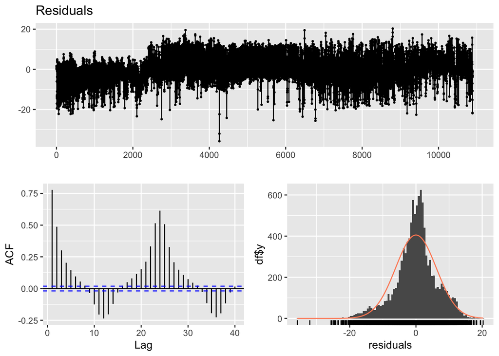

```
##
##  Breusch-Godfrey test for serial correlation of order up to 54
##
## data:  Residuals
## LM test = 8157.1, df = 54, p-value < 2.2e-16
```

```r
checkresiduals(model_4)
```

Previous approach is continued. This time temp data is excluded. The model we obtain still seems insufficient.

```r
model_5 <- lm(son$`p_data$production` ~ as.factor(hour) + CLOUD_LOW_LAYER_36.25_33 + CLOUD_LOW_LAYER_36.25_33.25 + CLOUD_LOW_LAYER_36.25_33.5 + CLOUD_LOW_LAYER_36.5_33 + CLOUD_LOW_LAYER_36.5_33.25 +
                 CLOUD_LOW_LAYER_36.5_33.5 + CLOUD_LOW_LAYER_36.75_33 + CLOUD_LOW_LAYER_36.75_33.25 + CLOUD_LOW_LAYER_36.75_33.5 + DSWRF_36.25_33 + DSWRF_36.25_33.25 + DSWRF_36.25_33.5 + DSWRF_36.5_33 +
                 DSWRF_36.5_33.25 + DSWRF_36.5_33.5 + DSWRF_36.75_33 + DSWRF_36.75_33.25 + DSWRF_36.75_33.5 + REL_HUMIDITY_36.25_33 + REL_HUMIDITY_36.25_33.25 + REL_HUMIDITY_36.25_33.5 + REL_HUMIDITY_36.5_33 +
                 REL_HUMIDITY_36.5_33.25 + REL_HUMIDITY_36.5_33.5 + REL_HUMIDITY_36.75_33 + REL_HUMIDITY_36.75_33.25 + REL_HUMIDITY_36.75_33.5,data=son)
summary(model_5)
```

```
##
## Call:
## lm(formula = son$`p_data$production` ~ as.factor(hour) + CLOUD_LOW_LAYER_36.25_33 +
##     CLOUD_LOW_LAYER_36.25_33.25 + CLOUD_LOW_LAYER_36.25_33.5 +
##     CLOUD_LOW_LAYER_36.5_33 + CLOUD_LOW_LAYER_36.5_33.25 + CLOUD_LOW_LAYER_36.5_33.5 +
##     CLOUD_LOW_LAYER_36.75_33 + CLOUD_LOW_LAYER_36.75_33.25 +
##     CLOUD_LOW_LAYER_36.75_33.5 + DSWRF_36.25_33 + DSWRF_36.25_33.25 +
##     DSWRF_36.25_33.5 + DSWRF_36.5_33 + DSWRF_36.5_33.25 + DSWRF_36.5_33.5 +
##     DSWRF_36.75_33 + DSWRF_36.75_33.25 + DSWRF_36.75_33.5 + REL_HUMIDITY_36.25_33 +
##     REL_HUMIDITY_36.25_33.25 + REL_HUMIDITY_36.25_33.5 + REL_HUMIDITY_36.5_33 +
##     REL_HUMIDITY_36.5_33.25 + REL_HUMIDITY_36.5_33.5 + REL_HUMIDITY_36.75_33 +
##     REL_HUMIDITY_36.75_33.25 + REL_HUMIDITY_36.75_33.5, data = son)
##
## Residuals:
##     Min      1Q  Median      3Q     Max
## -33.160  -2.581  -0.135   3.421  21.932
##
## Coefficients:
##                              Estimate Std. Error t value Pr(>|t|)
## (Intercept)                  4.065378   0.405833  10.017  < 2e-16 ***
## as.factor(hour)1            -0.001626   0.419510  -0.004 0.996908
## as.factor(hour)2            -0.014307   0.419672  -0.034 0.972806
## as.factor(hour)3            -0.015314   0.419955  -0.036 0.970912
## as.factor(hour)4             0.005272   0.420357   0.013 0.989994
## as.factor(hour)5             0.059349   0.420661   0.141 0.887806
## as.factor(hour)6             1.046486   0.420781   2.487 0.012897 *
## as.factor(hour)7             8.187520   0.420529  19.470  < 2e-16 ***
## as.factor(hour)8            18.969350   0.420836  45.075  < 2e-16 ***
## as.factor(hour)9            23.660422   0.423445  55.876  < 2e-16 ***
## as.factor(hour)10           15.429782   0.485650  31.771  < 2e-16 ***
## as.factor(hour)11           13.692307   0.504781  27.125  < 2e-16 ***
## as.factor(hour)12           12.165218   0.521539  23.326  < 2e-16 ***
## as.factor(hour)13           10.917846   0.534255  20.436  < 2e-16 ***
## as.factor(hour)14            9.308537   0.541391  17.194  < 2e-16 ***
## as.factor(hour)15            7.422702   0.542416  13.685  < 2e-16 ***
## as.factor(hour)16            5.981082   0.509848  11.731  < 2e-16 ***
## as.factor(hour)17           -1.120029   0.488780  -2.291 0.021955 *
## as.factor(hour)18           -6.259477   0.469820 -13.323  < 2e-16 ***
## as.factor(hour)19           -6.724578   0.454255 -14.804  < 2e-16 ***
## as.factor(hour)20           -5.489910   0.443011 -12.392  < 2e-16 ***
```

[output cut: 21 more lines]

```
## REL_HUMIDITY_36.25_33       -0.023672   0.013789  -1.717 0.086062 .
## REL_HUMIDITY_36.25_33.25    -0.091884   0.020913  -4.394 1.13e-05 ***
## REL_HUMIDITY_36.25_33.5      0.038264   0.013957   2.742 0.006124 **
## REL_HUMIDITY_36.5_33         0.059529   0.012958   4.594 4.40e-06 ***
## REL_HUMIDITY_36.5_33.25      0.004981   0.020318   0.245 0.806356
## REL_HUMIDITY_36.5_33.5      -0.037840   0.016327  -2.318 0.020492 *
## REL_HUMIDITY_36.75_33       -0.046410   0.011885  -3.905 9.49e-05 ***
## REL_HUMIDITY_36.75_33.25    -0.034152   0.016654  -2.051 0.040328 *
## REL_HUMIDITY_36.75_33.5      0.061321   0.012212   5.021 5.21e-07 ***
## ---
## Signif. codes:  0 '***' 0.001 '**' 0.01 '*' 0.05 '.' 0.1 ' ' 1
##
## Residual standard error: 6.319 on 10845 degrees of freedom
## Multiple R-squared:  0.8044, Adjusted R-squared:  0.8035
## F-statistic:   892 on 50 and 10845 DF,  p-value: < 2.2e-16
```

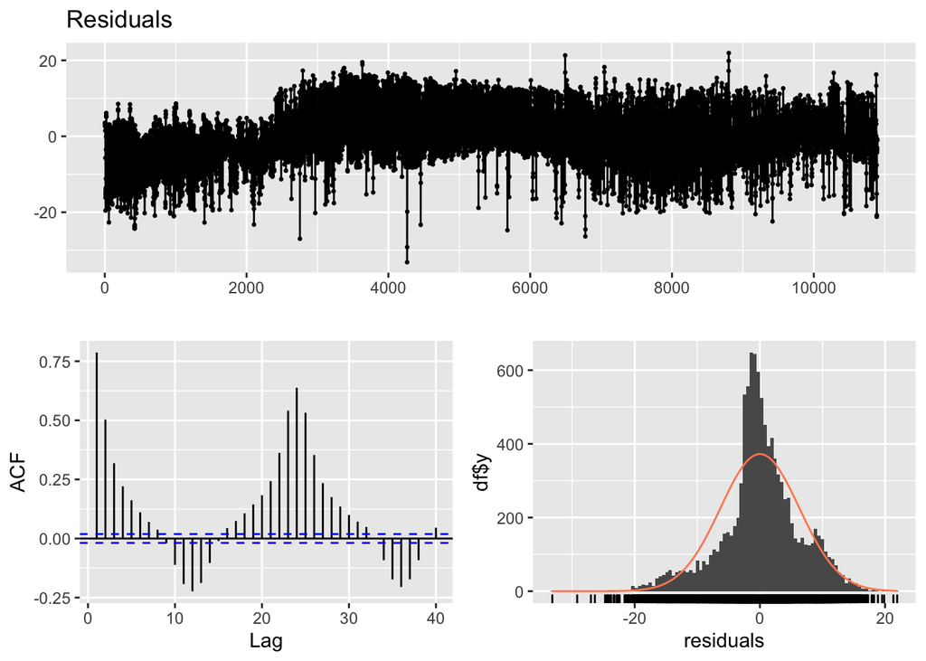

```
##
##  Breusch-Godfrey test for serial correlation of order up to 54
##
## data:  Residuals
## LM test = 8330.1, df = 54, p-value < 2.2e-16
```

```r
checkresiduals(model_5)
```

We looked at correlation between production and all given information about all 9 locations to determine which info at location “x” has the most importance for our forecast.

```r
cor(son$`p_data$production`,son$TEMP_36.25_33)
```

```
## [1] 0.4491453
```

```r
cor(son$`p_data$production`,son$TEMP_36.25_33.25) ## best one
```

```
## [1] 0.452816
```

```r
cor(son$`p_data$production`,son$TEMP_36.25_33.5)
```

```
## [1] 0.442955
```

```r
cor(son$`p_data$production`,son$TEMP_36.5_33)
```

```
## [1] 0.4340061
```

```r
cor(son$`p_data$production`,son$TEMP_36.5_33.25)
```

```
## [1] 0.4238261
```

```r
cor(son$`p_data$production`,son$TEMP_36.5_33.5)
```

```
## [1] 0.4436936
```

```r
cor(son$`p_data$production`,son$TEMP_36.75_33)
```

```
## [1] 0.4043814
```

```r
cor(son$`p_data$production`,son$TEMP_36.75_33.25)
```

```
## [1] 0.4110486
```

```r
cor(son$`p_data$production`,son$TEMP_36.75_33.5)
```

```
## [1] 0.4054575
```

```r
cor(son$`p_data$production`,son$CLOUD_LOW_LAYER_36.25_33) ## best one
```

```
## [1] -0.202496
```

```r
cor(son$`p_data$production`,son$CLOUD_LOW_LAYER_36.25_33.25)
```

```
## [1] -0.1931282
```

```r
cor(son$`p_data$production`,son$CLOUD_LOW_LAYER_36.25_33.5)
```

```
## [1] -0.1687432
```

```r
cor(son$`p_data$production`,son$CLOUD_LOW_LAYER_36.5_33)
```

```
## [1] -0.1901329
```

```r
cor(son$`p_data$production`,son$CLOUD_LOW_LAYER_36.5_33.25)
```

```
## [1] -0.1900479
```

```r
cor(son$`p_data$production`,son$CLOUD_LOW_LAYER_36.5_33.5)
```

```
## [1] -0.1782163
```

```r
cor(son$`p_data$production`,son$CLOUD_LOW_LAYER_36.75_33)
```

```
## [1] -0.1788434
```

```r
cor(son$`p_data$production`,son$CLOUD_LOW_LAYER_36.75_33.25)
```

```
## [1] -0.1868682
```

```r
cor(son$`p_data$production`,son$CLOUD_LOW_LAYER_36.75_33.5)
```

```
## [1] -0.176809
```

```r
cor(son$`p_data$production`,son$REL_HUMIDITY_36.25_33)
```

```
## [1] -0.4286221
```

```r
cor(son$`p_data$production`,son$REL_HUMIDITY_36.25_33.25)
```

```
## [1] -0.4393482
```

```r
cor(son$`p_data$production`,son$REL_HUMIDITY_36.25_33.5)
```

```
## [1] -0.4212124
```

```r
cor(son$`p_data$production`,son$REL_HUMIDITY_36.5_33)
```

```
## [1] -0.4889309
```

```r
cor(son$`p_data$production`,son$REL_HUMIDITY_36.5_33.25)
```

```
## [1] -0.4857072
```

```r
cor(son$`p_data$production`,son$REL_HUMIDITY_36.5_33.5)  ## best one
```

```
## [1] -0.507507
```

```r
cor(son$`p_data$production`,son$REL_HUMIDITY_36.75_33)
```

```
## [1] -0.4287819
```

```r
cor(son$`p_data$production`,son$REL_HUMIDITY_36.75_33.25)
```

```
## [1] -0.4506619
```

```r
cor(son$`p_data$production`,son$REL_HUMIDITY_36.75_33.5)
```

```
## [1] -0.4230526
```

```r
cor(son$`p_data$production`,son$DSWRF_36.25_33)
```

```
## [1] 0.6837411
```

```r
cor(son$`p_data$production`,son$DSWRF_36.25_33.25)
```

```
## [1] 0.684242
```

```r
cor(son$`p_data$production`,son$DSWRF_36.25_33.5)
```

```
## [1] 0.6822194
```

```r
cor(son$`p_data$production`,son$DSWRF_36.5_33) ## best one
```

```
## [1] 0.6887664
```

```r
cor(son$`p_data$production`,son$DSWRF_36.5_33.25)
```

```
## [1] 0.6884081
```

```r
cor(son$`p_data$production`,son$DSWRF_36.5_33.5)
```

```
## [1] 0.6836377
```

```r
cor(son$`p_data$production`,son$DSWRF_36.75_33)
```

```
## [1] 0.686794
```

```r
cor(son$`p_data$production`,son$DSWRF_36.75_33.25)
```

```
## [1] 0.6844871
```

```r
cor(son$`p_data$production`,son$DSWRF_36.75_33.5)
```

```
## [1] 0.6836865
```

According to correlation analysis we just made, we decided to add data which has highest correlations with production from each category

```r
model_6 <- lm(son$`p_data$production` ~ as.factor(hour) + TEMP_36.25_33.25 + CLOUD_LOW_LAYER_36.25_33 + REL_HUMIDITY_36.5_33.5 + DSWRF_36.5_33, data=son  )
summary(model_6)
```

```
##
## Call:
## lm(formula = son$`p_data$production` ~ as.factor(hour) + TEMP_36.25_33.25 +
##     CLOUD_LOW_LAYER_36.25_33 + REL_HUMIDITY_36.5_33.5 + DSWRF_36.5_33,
##     data = son)
##
## Residuals:
##     Min      1Q  Median      3Q     Max
## -33.563  -3.082   0.226   3.230  20.920
##
## Coefficients:
##                            Estimate Std. Error t value Pr(>|t|)
## (Intercept)              -5.561e+01  3.147e+00 -17.671  < 2e-16 ***
## as.factor(hour)1          8.066e-02  4.186e-01   0.193 0.847211
## as.factor(hour)2          1.503e-01  4.186e-01   0.359 0.719647
## as.factor(hour)3          2.237e-01  4.187e-01   0.534 0.593177
## as.factor(hour)4          3.037e-01  4.187e-01   0.725 0.468253
## as.factor(hour)5          4.115e-01  4.188e-01   0.983 0.325821
## as.factor(hour)6          1.443e+00  4.189e-01   3.445 0.000573 ***
## as.factor(hour)7          8.482e+00  4.188e-01  20.254  < 2e-16 ***
## as.factor(hour)8          1.914e+01  4.189e-01  45.690  < 2e-16 ***
## as.factor(hour)9          2.381e+01  4.205e-01  56.623  < 2e-16 ***
## as.factor(hour)10         1.720e+01  4.748e-01  36.223  < 2e-16 ***
## as.factor(hour)11         1.557e+01  4.929e-01  31.587  < 2e-16 ***
## as.factor(hour)12         1.412e+01  5.088e-01  27.752  < 2e-16 ***
## as.factor(hour)13         1.292e+01  5.202e-01  24.843  < 2e-16 ***
## as.factor(hour)14         1.135e+01  5.259e-01  21.574  < 2e-16 ***
## as.factor(hour)15         9.470e+00  5.258e-01  18.011  < 2e-16 ***
## as.factor(hour)16         7.599e+00  4.915e-01  15.461  < 2e-16 ***
## as.factor(hour)17         1.077e-01  4.731e-01   0.228 0.819987
## as.factor(hour)18        -5.428e+00  4.564e-01 -11.893  < 2e-16 ***
## as.factor(hour)19        -6.175e+00  4.435e-01 -13.922  < 2e-16 ***
## as.factor(hour)20        -4.956e+00  4.355e-01 -11.380  < 2e-16 ***
## as.factor(hour)21        -4.052e+00  4.306e-01  -9.410  < 2e-16 ***
## as.factor(hour)22        -1.315e-01  4.186e-01  -0.314 0.753418
## as.factor(hour)23        -6.801e-02  4.186e-01  -0.162 0.870946
## TEMP_36.25_33.25          2.023e-01  1.043e-02  19.394  < 2e-16 ***
## CLOUD_LOW_LAYER_36.25_33 -1.348e-02  2.492e-03  -5.410 6.43e-08 ***
## REL_HUMIDITY_36.5_33.5   -3.682e-02  5.321e-03  -6.920 4.78e-12 ***
## DSWRF_36.5_33             2.010e-02  5.241e-04  38.349  < 2e-16 ***
## ---
## Signif. codes:  0 '***' 0.001 '**' 0.01 '*' 0.05 '.' 0.1 ' ' 1
##
## Residual standard error: 6.307 on 10868 degrees of freedom
## Multiple R-squared:  0.8048, Adjusted R-squared:  0.8043
## F-statistic:  1659 on 27 and 10868 DF,  p-value: < 2.2e-16
```

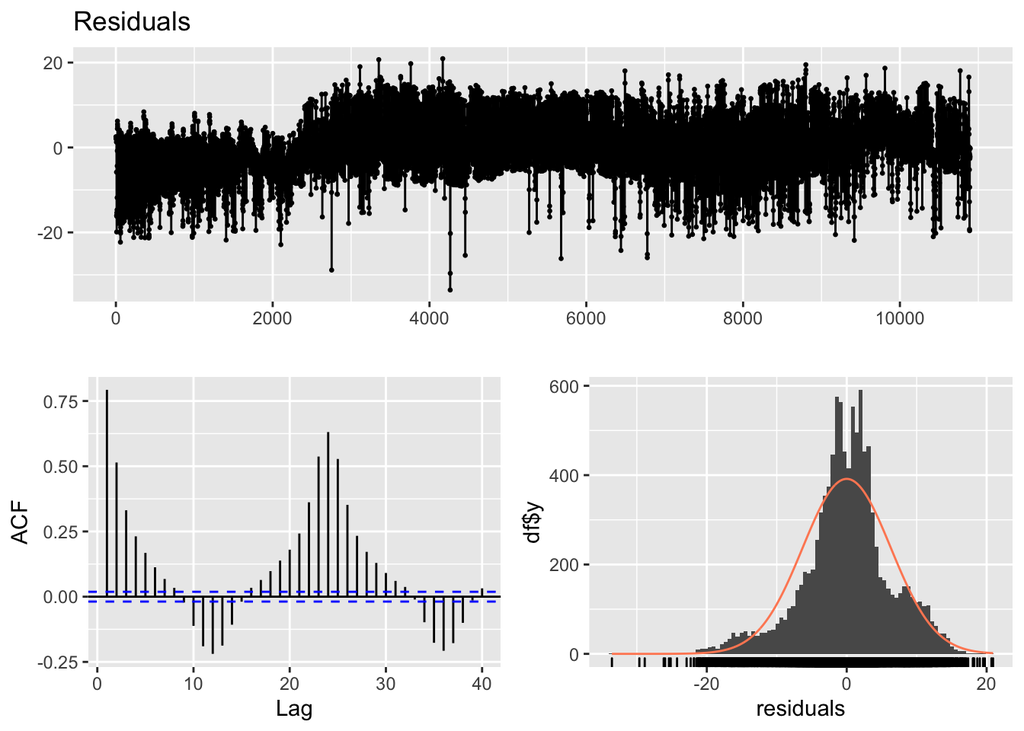

```
##
##  Breusch-Godfrey test for serial correlation of order up to 31
##
## data:  Residuals
## LM test = 8195, df = 31, p-value < 2.2e-16
```

```r
checkresiduals(model_6)
```

We converted our data to a time series.Then, we plotted the data and examined it and saw that there is a high seasonality in data. We also added seasonality and trend data to make our model even better.

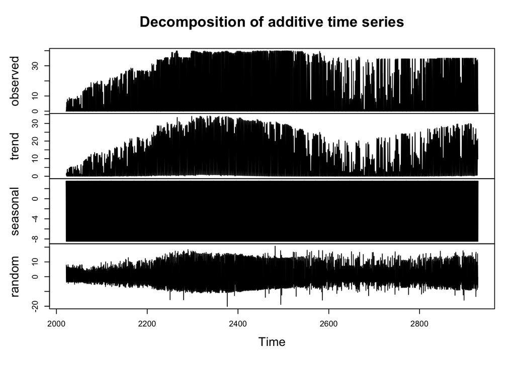

```r
son$date <- as.Date(son$date)
son_ts <- ts(son$`p_data$production`, freq=12, start=c(2021,2))
dec_son_ts <-decompose(son_ts,type="additive")
plot(dec_son_ts)
```

```r
son$trend=seq(0,10895,by=1)
son$quarter=seq(1,4,by=1)
```

Trend and seasonality variables didn’t improve our model significantly. The model still has high ACF values.

```r
model_7 <- lm(son$`p_data$production` ~as.factor(quarter) + as.factor(hour) + trend + TEMP_36.25_33.25 + CLOUD_LOW_LAYER_36.25_33 + REL_HUMIDITY_36.5_33.5 + DSWRF_36.5_33, data=son  )
summary(model_7)
```

```
##
## Call:
## lm(formula = son$`p_data$production` ~ as.factor(quarter) + as.factor(hour) +
##     trend + TEMP_36.25_33.25 + CLOUD_LOW_LAYER_36.25_33 + REL_HUMIDITY_36.5_33.5 +
##     DSWRF_36.5_33, data = son)
##
## Residuals:
##     Min      1Q  Median      3Q     Max
## -33.938  -3.237   0.069   3.652  21.591
##
## Coefficients: (3 not defined because of singularities)
##                            Estimate Std. Error t value Pr(>|t|)
## (Intercept)              -7.440e+01  3.107e+00 -23.947  < 2e-16 ***
## as.factor(quarter)2      -4.265e+00  4.155e-01 -10.266  < 2e-16 ***
## as.factor(quarter)3      -1.530e-01  4.039e-01  -0.379    0.705
## as.factor(quarter)4      -8.782e-02  4.038e-01  -0.217    0.828
## as.factor(hour)1          4.354e+00  4.153e-01  10.485  < 2e-16 ***
## as.factor(hour)2          3.180e-01  4.040e-01   0.787    0.431
## as.factor(hour)3          3.348e-01  4.039e-01   0.829    0.407
## as.factor(hour)4          3.342e-01  4.040e-01   0.827    0.408
## as.factor(hour)5          4.716e+00  4.146e-01  11.373  < 2e-16 ***
## as.factor(hour)6          1.635e+00  4.044e-01   4.043 5.31e-05 ***
## as.factor(hour)7          8.572e+00  4.040e-01  21.216  < 2e-16 ***
## as.factor(hour)8          1.908e+01  4.041e-01  47.212  < 2e-16 ***
## as.factor(hour)9          2.794e+01  4.107e-01  68.032  < 2e-16 ***
## as.factor(hour)10         1.674e+01  4.590e-01  36.471  < 2e-16 ***
## as.factor(hour)11         1.495e+01  4.764e-01  31.382  < 2e-16 ***
## as.factor(hour)12         1.335e+01  4.916e-01  27.152  < 2e-16 ***
## as.factor(hour)13         1.638e+01  4.520e-01  36.238  < 2e-16 ***
## as.factor(hour)14         1.068e+01  5.085e-01  21.009  < 2e-16 ***
## as.factor(hour)15         8.757e+00  5.082e-01  17.231  < 2e-16 ***
## as.factor(hour)16         6.981e+00  4.746e-01  14.709  < 2e-16 ***
## as.factor(hour)17         3.854e+00  4.215e-01   9.143  < 2e-16 ***
## as.factor(hour)18        -5.683e+00  4.406e-01 -12.899  < 2e-16 ***
## as.factor(hour)19        -6.399e+00  4.281e-01 -14.947  < 2e-16 ***
## as.factor(hour)20        -5.193e+00  4.202e-01 -12.357  < 2e-16 ***
## as.factor(hour)21                NA         NA      NA       NA
## as.factor(hour)22                NA         NA      NA       NA
## as.factor(hour)23                NA         NA      NA       NA
## trend                     5.531e-04  1.942e-05  28.476  < 2e-16 ***
## TEMP_36.25_33.25          2.558e-01  1.024e-02  24.990  < 2e-16 ***
## CLOUD_LOW_LAYER_36.25_33 -2.037e-02  2.417e-03  -8.431  < 2e-16 ***
## REL_HUMIDITY_36.5_33.5   -2.579e-02  5.147e-03  -5.010 5.54e-07 ***
## DSWRF_36.5_33             2.125e-02  5.072e-04  41.891  < 2e-16 ***
## ---
## Signif. codes:  0 '***' 0.001 '**' 0.01 '*' 0.05 '.' 0.1 ' ' 1
##
## Residual standard error: 6.084 on 10867 degrees of freedom
## Multiple R-squared:  0.8183, Adjusted R-squared:  0.8179
## F-statistic:  1748 on 28 and 10867 DF,  p-value: < 2.2e-16
```

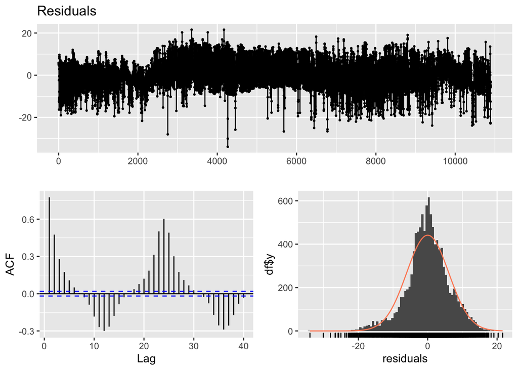

```
##
##  Breusch-Godfrey test for serial correlation of order up to 35
##
## data:  Residuals
## LM test = 7998.5, df = 35, p-value < 2.2e-16
```

```r
checkresiduals(model_7)
```

We decided that trend data is not efficient to improve our model. Thus, we tried to define a lag variable to check its performance.

```r
son$lag24 <- NA
son$lag24 <- dplyr::lag(son$`p_data$production`)
```

As can be seen, lag variable played a significant role in improving our model. But still some ACF values are not that good.

```r
model_8 <- lm(son$`p_data$production` ~as.factor(quarter)+ lag24 + as.factor(hour) + TEMP_36.25_33.25 + CLOUD_LOW_LAYER_36.25_33 + REL_HUMIDITY_36.5_33.5 + DSWRF_36.5_33, data=son  )
summary(model_8)
```

```
##
## Call:
## lm(formula = son$`p_data$production` ~ as.factor(quarter) + lag24 +
##     as.factor(hour) + TEMP_36.25_33.25 + CLOUD_LOW_LAYER_36.25_33 +
##     REL_HUMIDITY_36.5_33.5 + DSWRF_36.5_33, data = son)
##
## Residuals:
##     Min      1Q  Median      3Q     Max
## -35.493  -0.811   0.023   1.135  21.385
##
## Coefficients: (3 not defined because of singularities)
##                            Estimate Std. Error t value Pr(>|t|)
## (Intercept)              -1.332e+01  1.938e+00  -6.872 6.67e-12 ***
## as.factor(quarter)2       1.102e-01  2.636e-01   0.418   0.6759
## as.factor(quarter)3      -2.617e-02  2.546e-01  -0.103   0.9181
## as.factor(quarter)4      -1.361e-02  2.545e-01  -0.053   0.9573
## lag24                     8.337e-01  6.120e-03 136.226  < 2e-16 ***
## as.factor(hour)1         -8.966e-02  2.634e-01  -0.340   0.7335
## as.factor(hour)2          6.242e-02  2.545e-01   0.245   0.8063
## as.factor(hour)3          6.711e-02  2.545e-01   0.264   0.7920
## as.factor(hour)4          7.252e-02  2.546e-01   0.285   0.7758
## as.factor(hour)5          6.894e-03  2.632e-01   0.026   0.9791
## as.factor(hour)6          1.119e+00  2.548e-01   4.391 1.14e-05 ***
## as.factor(hour)7          7.624e+00  2.546e-01  29.940  < 2e-16 ***
## as.factor(hour)8          1.295e+01  2.587e-01  50.045  < 2e-16 ***
## as.factor(hour)9          9.150e+00  2.929e-01  31.234  < 2e-16 ***
## as.factor(hour)10         6.006e+00  3.006e-01  19.980  < 2e-16 ***
## as.factor(hour)11         4.820e+00  3.101e-01  15.545  < 2e-16 ***
## as.factor(hour)12         4.581e+00  3.172e-01  14.443  < 2e-16 ***
## as.factor(hour)13         4.224e+00  2.995e-01  14.106  < 2e-16 ***
## as.factor(hour)14         3.417e+00  3.253e-01  10.505  < 2e-16 ***
## as.factor(hour)15         2.447e+00  3.239e-01   7.554 4.55e-14 ***
## as.factor(hour)16        -5.999e-01  3.049e-01  -1.968   0.0491 *
## as.factor(hour)17        -6.126e+00  2.760e-01 -22.196  < 2e-16 ***
## as.factor(hour)18        -5.763e+00  2.774e-01 -20.774  < 2e-16 ***
## as.factor(hour)19        -2.075e+00  2.713e-01  -7.649 2.20e-14 ***
## as.factor(hour)20        -1.328e-01  2.672e-01  -0.497   0.6191
## as.factor(hour)21                NA         NA      NA       NA
## as.factor(hour)22                NA         NA      NA       NA
## as.factor(hour)23                NA         NA      NA       NA
## TEMP_36.25_33.25          4.830e-02  6.439e-03   7.500 6.85e-14 ***
## CLOUD_LOW_LAYER_36.25_33 -7.803e-03  1.515e-03  -5.150 2.65e-07 ***
## REL_HUMIDITY_36.5_33.5   -6.889e-03  3.241e-03  -2.126   0.0336 *
## DSWRF_36.5_33            -6.271e-04  3.530e-04  -1.777   0.0757 .
## ---
## Signif. codes:  0 '***' 0.001 '**' 0.01 '*' 0.05 '.' 0.1 ' ' 1
##
## Residual standard error: 3.833 on 10866 degrees of freedom
##   (1 observation deleted due to missingness)
## Multiple R-squared:  0.9279, Adjusted R-squared:  0.9277
## F-statistic:  4994 on 28 and 10866 DF,  p-value: < 2.2e-16
```

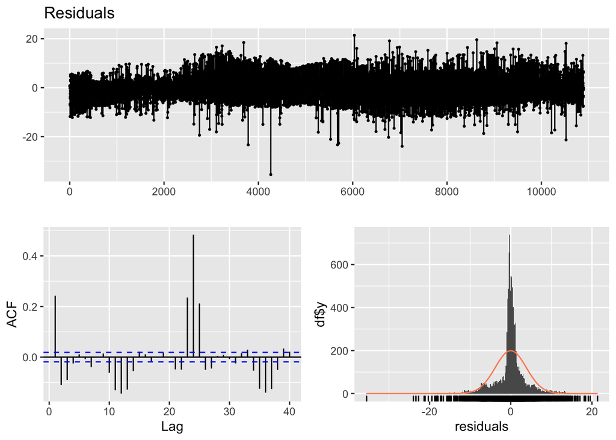

```
##
##  Breusch-Godfrey test for serial correlation of order up to 35
##
## data:  Residuals
## LM test = 3483, df = 35, p-value < 2.2e-16
```

```r
checkresiduals(model_8)
```

Then, just in case, we checked internal correlations to make sure our model does not suffer multicolinearity.

```r
cor(son$TEMP_36.25_33.25,son$CLOUD_LOW_LAYER_36.25_33)
```

```
## [1] -0.4035614
```

```r
cor(son$TEMP_36.25_33.25,son$REL_HUMIDITY_36.5_33.5)
```

```
## [1] -0.7129523
```

```r
cor(son$TEMP_36.25_33.25,son$DSWRF_36.5_33)
```

```
## [1] 0.4824475
```

```r
cor(son$CLOUD_LOW_LAYER_36.25_33,son$REL_HUMIDITY_36.5_33.5)
```

```
## [1] 0.5416938
```

```r
cor(son$CLOUD_LOW_LAYER_36.25_33,son$DSWRF_36.5_33)
```

```
## [1] -0.1912223
```

```r
cor(son$REL_HUMIDITY_36.5_33.5,son$DSWRF_36.5_33)
```

```
## [1] -0.6134198
```

In this model, we merged previous observations about multicolinearity with seasonality and lag variables. We eliminated some of the data chosen with respect to highest correlations with production, by examining multicolinearity among these best ones. We excluded humidity since it has the highest correlations compared to other variables in the model.

```r
model_9 <- lm(son$`p_data$production` ~as.factor(quarter)+ lag24 + as.factor(hour) + TEMP_36.25_33.25 + CLOUD_LOW_LAYER_36.25_33 + DSWRF_36.5_33, data=son  )
summary(model_9)
```

```
##
## Call:
## lm(formula = son$`p_data$production` ~ as.factor(quarter) + lag24 +
##     as.factor(hour) + TEMP_36.25_33.25 + CLOUD_LOW_LAYER_36.25_33 +
##     DSWRF_36.5_33, data = son)
##
## Residuals:
##     Min      1Q  Median      3Q     Max
## -35.543  -0.793  -0.007   1.114  21.315
##
## Coefficients: (3 not defined because of singularities)
##                            Estimate Std. Error t value Pr(>|t|)
## (Intercept)              -1.558e+01  1.620e+00  -9.617  < 2e-16 ***
## as.factor(quarter)2       1.023e-01  2.636e-01   0.388   0.6980
## as.factor(quarter)3      -2.084e-02  2.546e-01  -0.082   0.9348
## as.factor(quarter)4      -1.175e-02  2.546e-01  -0.046   0.9632
## lag24                     8.346e-01  6.107e-03 136.663  < 2e-16 ***
## as.factor(hour)1         -8.421e-02  2.634e-01  -0.320   0.7492
## as.factor(hour)2          5.247e-02  2.545e-01   0.206   0.8367
## as.factor(hour)3          5.904e-02  2.545e-01   0.232   0.8165
## as.factor(hour)4          6.361e-02  2.546e-01   0.250   0.8027
## as.factor(hour)5          3.470e-03  2.632e-01   0.013   0.9895
## as.factor(hour)6          1.099e+00  2.547e-01   4.315 1.61e-05 ***
## as.factor(hour)7          7.609e+00  2.546e-01  29.889  < 2e-16 ***
## as.factor(hour)8          1.295e+01  2.588e-01  50.025  < 2e-16 ***
## as.factor(hour)9          9.166e+00  2.929e-01  31.294  < 2e-16 ***
## as.factor(hour)10         5.973e+00  3.003e-01  19.894  < 2e-16 ***
## as.factor(hour)11         4.799e+00  3.100e-01  15.483  < 2e-16 ***
## as.factor(hour)12         4.571e+00  3.172e-01  14.409  < 2e-16 ***
## as.factor(hour)13         4.230e+00  2.995e-01  14.122  < 2e-16 ***
## as.factor(hour)14         3.414e+00  3.253e-01  10.493  < 2e-16 ***
## as.factor(hour)15         2.451e+00  3.240e-01   7.567 4.13e-14 ***
## as.factor(hour)16        -5.727e-01  3.046e-01  -1.880   0.0601 .
## as.factor(hour)17        -6.090e+00  2.755e-01 -22.103  < 2e-16 ***
## as.factor(hour)18        -5.742e+00  2.773e-01 -20.708  < 2e-16 ***
## as.factor(hour)19        -2.060e+00  2.712e-01  -7.596 3.29e-14 ***
## as.factor(hour)20        -1.293e-01  2.672e-01  -0.484   0.6286
## as.factor(hour)21                NA         NA      NA       NA
## as.factor(hour)22                NA         NA      NA       NA
## as.factor(hour)23                NA         NA      NA       NA
## TEMP_36.25_33.25          5.499e-02  5.618e-03   9.788  < 2e-16 ***
## CLOUD_LOW_LAYER_36.25_33 -9.219e-03  1.361e-03  -6.773 1.33e-11 ***
## DSWRF_36.5_33            -4.966e-04  3.477e-04  -1.428   0.1532
## ---
## Signif. codes:  0 '***' 0.001 '**' 0.01 '*' 0.05 '.' 0.1 ' ' 1
##
## Residual standard error: 3.833 on 10867 degrees of freedom
##   (1 observation deleted due to missingness)
## Multiple R-squared:  0.9279, Adjusted R-squared:  0.9277
## F-statistic:  5177 on 27 and 10867 DF,  p-value: < 2.2e-16
```

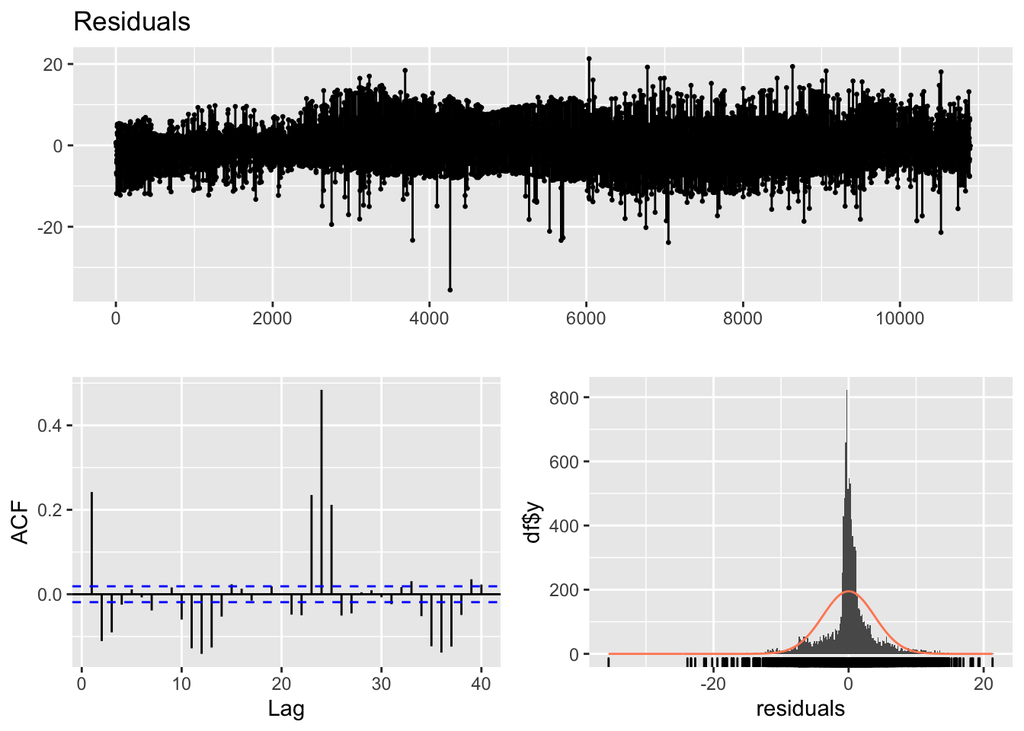

```
##
##  Breusch-Godfrey test for serial correlation of order up to 34
##
## data:  Residuals
## LM test = 3476.1, df = 34, p-value < 2.2e-16
```

```r
checkresiduals(model_9)
```

In this model, we excluded temp too. Because temp also had high correlations with other variables. However, there is no improvement in terms of R-squared values.

```r
model_10 <- lm(son$`p_data$production` ~as.factor(quarter)+ lag24 + as.factor(hour) + CLOUD_LOW_LAYER_36.25_33 + DSWRF_36.5_33, data=son  )
summary(model_10)
```

```
##
## Call:
## lm(formula = son$`p_data$production` ~ as.factor(quarter) + lag24 +
##     as.factor(hour) + CLOUD_LOW_LAYER_36.25_33 + DSWRF_36.5_33,
##     data = son)
##
## Residuals:
##     Min      1Q  Median      3Q     Max
## -35.136  -0.491  -0.177   1.075  21.691
##
## Coefficients: (3 not defined because of singularities)
##                            Estimate Std. Error t value Pr(>|t|)
## (Intercept)               0.1772937  0.1818515   0.975  0.32961
## as.factor(quarter)2       0.0107071  0.2646225   0.040  0.96773
## as.factor(quarter)3       0.0048070  0.2556842   0.019  0.98500
## as.factor(quarter)4       0.0010545  0.2556837   0.004  0.99671
## lag24                     0.8489201  0.0059545 142.569  < 2e-16 ***
## as.factor(hour)1         -0.0072453  0.2644511  -0.027  0.97814
## as.factor(hour)2         -0.0009735  0.2555427  -0.004  0.99696
## as.factor(hour)3          0.0046858  0.2555432   0.018  0.98537
## as.factor(hour)4          0.0091142  0.2556855   0.036  0.97157
## as.factor(hour)5          0.0262567  0.2643678   0.099  0.92089
## as.factor(hour)6          0.9953925  0.2555436   3.895 9.87e-05 ***
## as.factor(hour)7          7.5421720  0.2556018  29.508  < 2e-16 ***
## as.factor(hour)8         12.8542004  0.2597339  49.490  < 2e-16 ***
## as.factor(hour)9          9.0611938  0.2939730  30.823  < 2e-16 ***
## as.factor(hour)10         5.4525845  0.2967935  18.372  < 2e-16 ***
## as.factor(hour)11         4.2662977  0.3064810  13.920  < 2e-16 ***
## as.factor(hour)12         4.0390434  0.3138707  12.868  < 2e-16 ***
## as.factor(hour)13         3.7823279  0.2972969  12.722  < 2e-16 ***
## as.factor(hour)14         2.8471668  0.3215289   8.855  < 2e-16 ***
## as.factor(hour)15         1.9122587  0.3206283   5.964 2.54e-09 ***
## as.factor(hour)16        -0.9846552  0.3030315  -3.249  0.00116 **
## as.factor(hour)17        -6.3243527  0.2756712 -22.942  < 2e-16 ***
## as.factor(hour)18        -5.9717404  0.2775116 -21.519  < 2e-16 ***
## as.factor(hour)19        -2.1942413  0.2720540  -8.065 8.06e-16 ***
## as.factor(hour)20        -0.2402825  0.2681435  -0.896  0.37022
## as.factor(hour)21                NA         NA      NA       NA
## as.factor(hour)22                NA         NA      NA       NA
## as.factor(hour)23                NA         NA      NA       NA
## CLOUD_LOW_LAYER_36.25_33 -0.0125916  0.0013227  -9.520  < 2e-16 ***
## DSWRF_36.5_33             0.0002286  0.0003412   0.670  0.50290
## ---
## Signif. codes:  0 '***' 0.001 '**' 0.01 '*' 0.05 '.' 0.1 ' ' 1
##
## Residual standard error: 3.85 on 10868 degrees of freedom
##   (1 observation deleted due to missingness)
## Multiple R-squared:  0.9272, Adjusted R-squared:  0.9271
## F-statistic:  5326 on 26 and 10868 DF,  p-value: < 2.2e-16
```

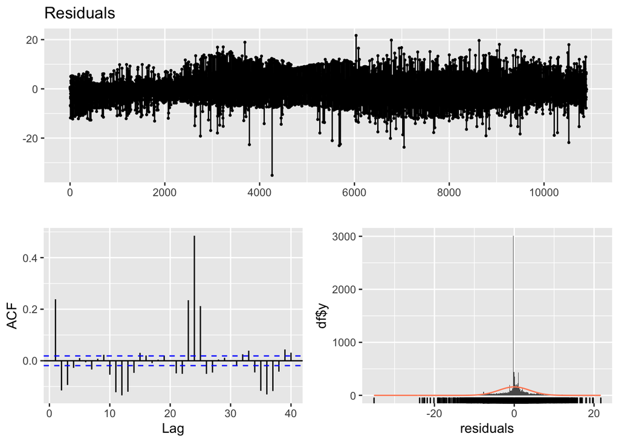

```
##
##  Breusch-Godfrey test for serial correlation of order up to 33
##
## data:  Residuals
## LM test = 3523.4, df = 33, p-value < 2.2e-16
```

```r
checkresiduals(model_10)
```

Model still has a close R-squared value compared to the previous model. Therefore, to eliminate multicolinearity further, we excluded DSWRF as well.

```r
model_11 <- lm(son$`p_data$production` ~as.factor(quarter)+ lag24 + as.factor(hour) + CLOUD_LOW_LAYER_36.25_33, data=son  )
summary(model_11)
```

```
##
## Call:
## lm(formula = son$`p_data$production` ~ as.factor(quarter) + lag24 +
##     as.factor(hour) + CLOUD_LOW_LAYER_36.25_33, data = son)
##
## Residuals:
##     Min      1Q  Median      3Q     Max
## -35.107  -0.477  -0.181   1.095  21.720
##
## Coefficients: (3 not defined because of singularities)
##                           Estimate Std. Error t value Pr(>|t|)
## (Intercept)               0.181037   0.181761   0.996  0.31926
## as.factor(quarter)2       0.056240   0.255739   0.220  0.82594
## as.factor(quarter)3       0.004908   0.255678   0.019  0.98468
## as.factor(quarter)4       0.001077   0.255677   0.004  0.99664
## lag24                     0.851030   0.005053 168.421  < 2e-16 ***
## as.factor(hour)1         -0.052705   0.255591  -0.206  0.83663
## as.factor(hour)2         -0.000994   0.255536  -0.004  0.99690
## as.factor(hour)3          0.004785   0.255537   0.019  0.98506
## as.factor(hour)4          0.009307   0.255679   0.036  0.97096
## as.factor(hour)5         -0.019026   0.255575  -0.074  0.94066
## as.factor(hour)6          0.995518   0.255537   3.896 9.85e-05 ***
## as.factor(hour)7          7.541818   0.255595  29.507  < 2e-16 ***
## as.factor(hour)8         12.843562   0.259242  49.543  < 2e-16 ***
## as.factor(hour)9          8.990165   0.274182  32.789  < 2e-16 ***
## as.factor(hour)10         5.502527   0.287272  19.154  < 2e-16 ***
## as.factor(hour)11         4.330191   0.291257  14.867  < 2e-16 ***
## as.factor(hour)12         4.116130   0.292012  14.096  < 2e-16 ***
## as.factor(hour)13         3.823092   0.290996  13.138  < 2e-16 ***
## as.factor(hour)14         2.938228   0.291379  10.084  < 2e-16 ***
## as.factor(hour)15         2.005566   0.288792   6.945 4.01e-12 ***
## as.factor(hour)16        -0.916072   0.285209  -3.212  0.00132 **
## as.factor(hour)17        -6.309139   0.274727 -22.965  < 2e-16 ***
## as.factor(hour)18        -5.909805   0.261653 -22.586  < 2e-16 ***
## as.factor(hour)19        -2.132970   0.256214  -8.325  < 2e-16 ***
## as.factor(hour)20        -0.186362   0.255773  -0.729  0.46625
## as.factor(hour)21               NA         NA      NA       NA
## as.factor(hour)22               NA         NA      NA       NA
## as.factor(hour)23               NA         NA      NA       NA
## CLOUD_LOW_LAYER_36.25_33 -0.012857   0.001262 -10.190  < 2e-16 ***
## ---
## Signif. codes:  0 '***' 0.001 '**' 0.01 '*' 0.05 '.' 0.1 ' ' 1
##
## Residual standard error: 3.85 on 10869 degrees of freedom
##   (1 observation deleted due to missingness)
## Multiple R-squared:  0.9272, Adjusted R-squared:  0.9271
## F-statistic:  5540 on 25 and 10869 DF,  p-value: < 2.2e-16
```

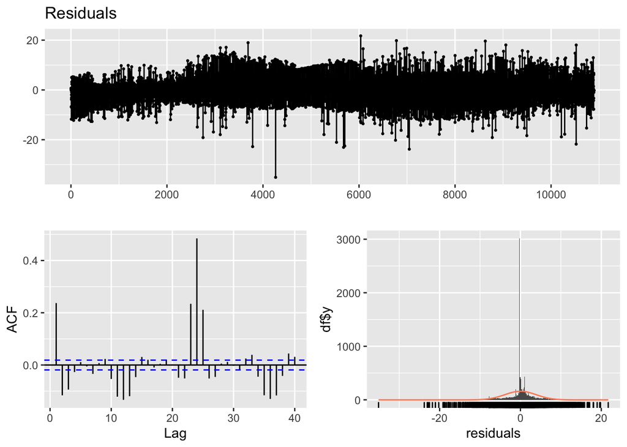

```
##
##  Breusch-Godfrey test for serial correlation of order up to 32
##
## data:  Residuals
## LM test = 3456.7, df = 32, p-value < 2.2e-16
```

```r
checkresiduals(model_11)
```

Since DSWRF and hour variables have high correlations, we tried excluding hour instead of DSWRF variable

```r
model_12 <- lm(son$`p_data$production` ~as.factor(quarter)+ lag24  + CLOUD_LOW_LAYER_36.25_33 + DSWRF_36.5_33, data=son  )
summary(model_12)
```

```
##
## Call:
## lm(formula = son$`p_data$production` ~ as.factor(quarter) + lag24 +
##     CLOUD_LOW_LAYER_36.25_33 + DSWRF_36.5_33, data = son)
##
## Residuals:
##     Min      1Q  Median      3Q     Max
## -35.319  -2.323  -0.755   1.740  26.610
##
## Coefficients:
##                            Estimate Std. Error t value Pr(>|t|)
## (Intercept)               2.7762859  0.1158152  23.972  < 2e-16 ***
## as.factor(quarter)2      -1.8007273  0.1450214 -12.417  < 2e-16 ***
## as.factor(quarter)3      -2.0212867  0.1448098 -13.958  < 2e-16 ***
## as.factor(quarter)4      -0.4282451  0.1450035  -2.953  0.00315 **
## lag24                     1.0615448  0.0062150 170.803  < 2e-16 ***
## CLOUD_LOW_LAYER_36.25_33 -0.0158659  0.0016628  -9.541  < 2e-16 ***
## DSWRF_36.5_33            -0.0089025  0.0003057 -29.126  < 2e-16 ***
## ---
## Signif. codes:  0 '***' 0.001 '**' 0.01 '*' 0.05 '.' 0.1 ' ' 1
##
## Residual standard error: 5.343 on 10888 degrees of freedom
##   (1 observation deleted due to missingness)
## Multiple R-squared:  0.8596, Adjusted R-squared:  0.8595
## F-statistic: 1.111e+04 on 6 and 10888 DF,  p-value: < 2.2e-16
```

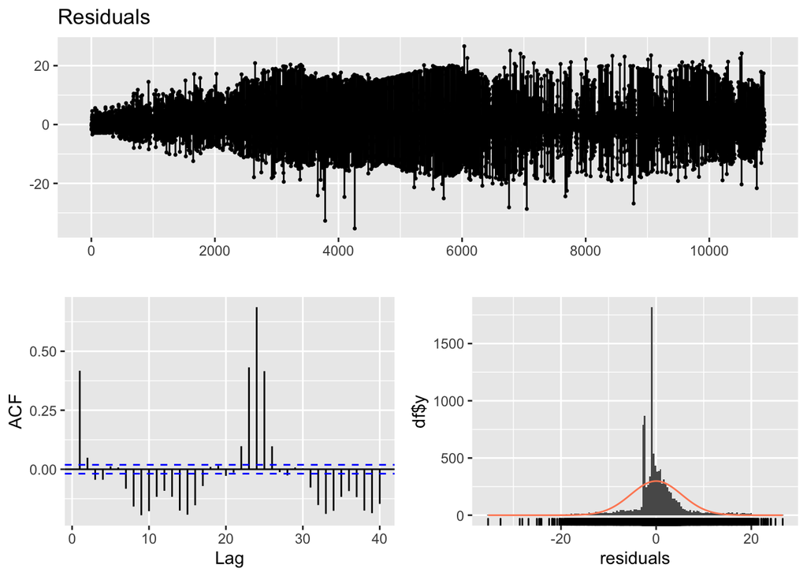

```
##
##  Breusch-Godfrey test for serial correlation of order up to 10
##
## data:  Residuals
## LM test = 2958, df = 10, p-value < 2.2e-16
```

```r
checkresiduals(model_12)
```

We updated our data 2 times to achieve better results with our model.

```r
## as of may 27 new data is introduced
new_production <- read.csv("2022-05-27_production.csv")
new_weather <-  read.csv("2022-05-27_weather.csv")
wide_new_weather <- dcast(new_weather, date + hour   ~ variable+lat+lon, value.variable = "var")


new_production <- new_production[c(10897:11352),]
wide_new_weather <- wide_new_weather[c(11041:11664),]

rownames(new_production) <- NULL
rownames(wide_new_weather) <- NULL

wide_new_weather <- wide_new_weather[c(1:456),]
rownames(wide_new_weather) <- NULL

new_son <- cbind(wide_new_weather,new_production$production)
new_son$trend=seq(0,455,by=1)
new_son$quarter=seq(1,4,by=1)

new_son$lag24 <- NA
new_son$lag24 <- dplyr::lag(new_son$`new_production$production`)


colnames(new_son)  <- colnames(son)
son_son <- rbind(son,new_son)

## as of may 30 new data is introduced
new_production_30 <- read.csv("2022-05-29_production.csv")
new_weather_30 <-  read.csv("2022-05-29_weather.csv")
wide_new_weather_30 <- dcast(new_weather, date + hour   ~ variable+lat+lon, value.variable = "var")

wide_new_weather_30 <- wide_new_weather_30[c(11497:11544),]

rownames(new_production_30) <- NULL
rownames(wide_new_weather_30) <- NULL

new_son_30 <- cbind(wide_new_weather_30,new_production_30$production)
new_son_30$trend=seq(0,47,by=1)
new_son_30$quarter=seq(1,4,by=1)

new_son_30$lag24 <- NA
new_son_30$lag24 <- dplyr::lag(new_son_30$`new_production_30$production`)

colnames(new_son_30)  <- colnames(son)
son_son_30 <- rbind(son_son,new_son_30)
```

```r
#prediction_set = son$tahmin
#tahmin=predict(model_11,newdata=)
#for(i in 1:24) {
#  prediction_set[i,1] = predict(model_11,newdata = prediction_set[i,])
#  if(i<25){
#    prediction_set[i+1,"lag24"] = prediction_set[i,1]
#  }
#}

#tail(tahmin,n=24
#     )
```